# Analisis Pola Waktu dan Prefensi Genre Film untuk Mengidentifikasi *Peak Business Time* pada Database Sakila

Nama : Aida Hikmallah NIM : M0725087 Kelas : D Mata kuliah: Sistem Informasi Manajemen

2026-05-26

# 1 Pendahuluan

## 1.1 Latar Belakang

Di era digital, industri hiburan dituntut mengambil keputusan berbasis data (*data-driven decision*) untuk meningkatkan efisiensi operasional. Salah satu model bisnis yang mendasari layanan *streaming* adalah penyewaan film. Analisis ini menggunakan dataset **Sakila** dari MySQL yang berisi data transaksi penyewaan film, termasuk informasi waktu (tanggal dan jam) serta kategori film.

Permasalahan utama dalam bisnis ini adalah *demand volatility*, yaitu ketidakseimbangan volume transaksi pada waktu tertentu (*Peak Business Time*) yang dapat menyebabkan **under-capacity saat jam sibuk** dan **over-capacity saat jam sepi**.

Oleh karena itu, analisis ini berfokus pada variabel waktu (jam dan tipe hari) serta preferensi genre untuk mengidentifikasi pola *Peak Business Time*, sehingga dapat mendukung efisiensi operasional dan pengambilan keputusan bisnis.

## 1.2 Insight

Pada database Sakila terdapat data transaksi penyewaan film yang menyimpan informasi waktu rental pelanggan dan kategori (genre) film. Berdasarkan data tersebut, dipilih insight mengenai kombinasi pola waktu penyewaan dengan preferensi genre film untuk mengidentifikasi *peak business time* yang spesifik bagi setiap kategori produk.Insight ini dipilih karena perilaku pelanggan tidak hanya dipengaruhi oleh kapan mereka bertransaksi, tetapi juga oleh jenis konten yang mereka cari pada waktu tertentu. Dengan memetakan hubungan temporal ini, perusahaan dapat mengoptimalkan strategi operasional bisnis.

## 1.3 Deskripsi Data

Data yang digunakan pada analisis ini berfokus pada data transaksi penyewaan film yang tersimpan pada tabel `rental` sebagai sumber data utama. Tabel tersebut menyimpan informasi mengenai waktu pelanggan melakukan penyewaan film.

Selain tabel `rental`, analisis ini juga menggunakan beberapa tabel pendukung untuk memperdalam analisis, yaitu :

1. Tabel inventory
2. Tabel film
3. Tabel film_category
4. Tabel category

Variabel utama yang digunakan adalah `rental_date` pada tabel `rental` dan `name` (genre) pada tabel `category`. Variabel `rental_date` bertipe *datetime* yang memuat informasi tanggal serta waktu penyewaan film. Melalui variabel tersebut, proses transformasi data dijalankan untuk menghasilkan variabel baru, yaitu jam rental (`rental_hour`). Transformasi ini dilakukan agar pola aktivitas pelanggan dapat diamati secara lebih detail dan spesifik.

## 1.4 Rumusan Masalah

Berdasarkan latar belakang operasional pada bisnis penyewaan film di database Sakila, maka masalah yang akan dikaji dalam analisis ini dirumuskan sebagai berikut:

1. Bagaimana pola distribusi volume transaksi penyewaan film secara temporal berdasarkan dimensi jam dan hari dalam seminggu?
2. Kapan jendela waktu puncak aktivitas pelanggan (*Peak Business Time*) tertinggi terjadi di dalam ekosistem bisnis Sakila?
3. Apakah pergeseran dimensi waktu (jam bertransaksi dan tipe hari) memiliki pengaruh yang signifikan secara statistik terhadap perubahan preferensi genre film yang dipilih oleh pelanggan?
4. Bagaimana bentuk rekomendasi taktis manajemen operasional yang efisien dalam mengelola kapasitas dan stok produk berdasarkan karakteristik perilaku pelanggan tersebut?

## 1.5 Tujuan Analisis

1. Memetakan pola distribusi transaksi penyewaan secara deskriptif untuk mengidentifikasi fluktuasi trafik pelanggan berdasarkan waktu.
2. Menentukan waktu puncak bisnis (*Peak Business Time*) yang kritis secara presisi guna mendukung kesiapan kapasitas operasional.
3. Menguji dan membuktikan secara ilmiah menggunakan pemodelan Regresi Logistik Multinomial mengenai ada atau tidaknya pengaruh faktor temporal terhadap dinamika selera genre film pelanggan.
4. Merumuskan strategi operasional terpusat dan efisiensi biaya yang tepat sasaran bagi manajemen untuk mengoptimalkan profitabilitas bisnis.

# 2 Persiapan Data

## 2.1 Library yang digunakan

```r
library(DBI)
library(RMySQL)
library(dplyr)
library(ggplot2)
library(lubridate)
library(scales)
library(nnet)
```

## 2.2 Koneksi Database

```r
con <- dbConnect(
  MySQL(),
  user = "root",
  password = "******",
  dbname = "sakila",
  host = "localhost"
)
```

# 3 Data Cleaning dan Preparation

## 3.1 Import dan Transformasi Data

```r
df <- dbGetQuery(con, "
SELECT
    r.rental_id,
    r.customer_id,
    r.inventory_id,
    r.rental_date,

    HOUR(r.rental_date) AS rental_hour,
    DAYNAME(r.rental_date) AS rental_day,
    DATE(r.rental_date) AS rental_day_only,

    CASE
        WHEN DAYOFWEEK(r.rental_date) IN (1,7) THEN 'Weekend'
        ELSE 'Weekday'
    END AS day_type,

    c.name AS category_name

FROM rental r
JOIN inventory i ON r.inventory_id = i.inventory_id
JOIN film f ON i.film_id = f.film_id
JOIN film_category fc ON f.film_id = fc.film_id
JOIN category c ON fc.category_id = c.category_id
")
head(df)
```

```
##   rental_id customer_id inventory_id         rental_date rental_hour rental_day
## 1     10895          77           93 2005-08-02 01:16:59           1    Tuesday
## 2     12268          39           93 2005-08-18 04:26:54           4   Thursday
## 3      3150          34           94 2005-06-20 20:35:28          20     Monday
## 4      5072         254           94 2005-07-09 05:01:58           5   Saturday
## 5      9080         276           94 2005-07-30 08:02:39           8   Saturday
## 6     14603          26           94 2005-08-21 17:51:06          17     Sunday
##   rental_day_only day_type category_name
## 1      2005-08-02  Weekday        Action
## 2      2005-08-18  Weekday        Action
## 3      2005-06-20  Weekday        Action
## 4      2005-07-09  Weekend        Action
## 5      2005-07-30  Weekend        Action
## 6      2005-08-21  Weekend        Action
```

Syntax di atas digunakan untuk mengimport dan mentransformasi data dari tabel rental dengan melakukan penggabungan (join) terhadap beberapa tabel terkait, yaitu `inventory`, `film`, `film_category`, dan `category`. Proses ini tidak hanya mengekstrak informasi temporal dari variabel `rental_date`, seperti `rental_hour`, `rental_day`, dan `rental_day_only`, tetapi juga memperkaya dataset dengan variabel kategorikal tambahan berupa `category_name` yang merepresentasikan genre film.

Selain itu, dibentuk variabel baru `day_type` yang mengelompokkan hari menjadi *weekday* (Senin–Jumat) dan *weekend* (Sabtu–Minggu). Dengan demikian, hasil transformasi ini menghasilkan dataset yang lebih komprehensif karena menggabungkan dimensi waktu dan preferensi konten.

Dataset hasil transformasi ini kemudian dapat digunakan sebagai dasar analisis untuk mengeksplorasi pola perilaku pelanggan dalam penyewaan film berdasarkan waktu dan jenis genre yang dipilih.

## 3.2 Pengecekan missing value

```r
colSums(is.na(df))
```

```
##       rental_id     customer_id    inventory_id     rental_date     rental_hour
##               0               0               0               0               0
##      rental_day rental_day_only        day_type   category_name
##               0               0               0               0
```

## 3.3 Pengecekan duplicate data

```r
sum(duplicated(df))
```

```
## [1] 0
```

# 4 Key Performance Indicator (KPI)

```r
total_rental <- nrow(df)

hourly <- df %>%
  group_by(rental_hour) %>%
  summarise(total = n(), .groups = "drop")

peak_hour <- hourly$rental_hour[which.max(hourly$total)]

daily <- df %>%
  group_by(rental_day) %>%
  summarise(total = n(), .groups = "drop")

peak_day <- daily$rental_day[which.max(daily$total)]
```

Kode di atas digunakan untuk melakukan agregasi data guna mengetahui pola umum penyewaan berdasarkan waktu. Pertama, variabel `total_rental` menghitung jumlah keseluruhan data pada dataset `df`, yaitu total transaksi penyewaan.

Selanjutnya, data dikelompokkan berdasarkan `rental_hour` untuk menghitung jumlah penyewaan pada setiap jam. Hasil pengelompokan ini disimpan dalam objek `hourly`, kemudian ditentukan jam dengan jumlah penyewaan tertinggi (`peak_hour`) dengan cara mencari nilai maksimum dari total penyewaan perjam.

Selain itu, dilakukan pengelompokan berdasarkan `rental_day` untuk mengetahui jumlah penyewaan pada setiap hari dalam seminggu. Hasilnya disimpan dalam objek `daily`, kemudian ditentukan hari dengan jumlah penyewaan tertinggi (`peak_day`) berdasarkan nilai maksimum jumlah transaksi.

Hasil proses ini memberikan gambaran awal mengenai waktu (jam dan hari) dengan tingkat aktivitas penyewaan tertinggi dalam dataset.

## 16044

Total Rental

## 15:00

Peak Hour

## Tuesday

Peak Day

# 5 EDA (Exploratory Data Analysis)

## 5.1 Peak Hour

```r
data_peak_hour <- dbGetQuery(con,"
SELECT
    HOUR(rental_date) AS hour,
    COUNT(*) AS total_rental
FROM rental
GROUP BY HOUR(rental_date)
ORDER BY hour;
")

data_peak_hour
```

```
##    hour total_rental
## 1     0          694
## 2     1          649
## 3     2          630
## 4     3          684
## 5     4          681
## 6     5          648
## 7     6          647
## 8     7          667
## 9     8          696
## 10    9          652
## 11   10          673
## 12   11          663
## 13   12          632
## 14   13          645
## 15   14          653
## 16   15          887
## 17   16          664
## 18   17          634
## 19   18          688
## 20   19          676
## 21   20          658
## 22   21          671
## 23   22          610
## 24   23          642
```

Syntax di atas digunakan untuk menganalisis distribusi jumlah penyewaan berdasarkan jam dalam satu hari. Data diambil dari tabel `rental`, kemudian variabel `rental_date` diekstrak menjadi komponen jam dengan fungsi `HOUR()` yang menghasilkan nilai `hour` dengan rentang nilai 0-23. Selanjutnya, data dikelompokkan berdasarkan `hour` untuk menghitung jumlah transaksi penyewaan pada masing-masing jam. Fungsi `COUNT(*)` digunakan untuk memperoleh total penyewaan pada setiap jam yang disimpan dalam variabel `total_rental`. Terakhir, data diurutkan berdasarkan nilai terkecil hingga terbesar menggunakan `ORDER BY hour`.

## 5.2 Peak Rental Day

```r
data_peak_day <- dbGetQuery(con, "
SELECT
    DAYNAME(rental_date) AS day,
    COUNT(*) AS total_rental
FROM rental
GROUP BY DAYNAME(rental_date)
ORDER BY total_rental DESC;
")

data_peak_day
```

```
##         day total_rental
## 1   Tuesday         2463
## 2    Sunday         2320
## 3  Saturday         2311
## 4    Friday         2272
## 5    Monday         2247
## 6 Wednesday         2231
## 7  Thursday         2200
```

Syntax di atas digunakan untuk menganalisis distribusi penyewaan berdasarkan hari dalam satu minggu. Data diambil dari tabel `rental`, kemudian variabel `rental_date` diekstrak menjadi nama hari menggunakan fungsi `DAYNAME()` sehingga diperoleh variabel `day`. Selanjutnya, data dikelompokkan berdasarkan `day` untuk menghitung jumlah transaksi penyewaan pada masing-masing hari. Fungsi `COUNT(*)` digunakan untuk menghitung total penyewaan yang disimpan dalam kolom `total_rental`. Hasil diurutkan berdasarkan `total_rental` terbesar menggunakan `ORDER BY total_rental DESC`.

## 5.3 Distribusi Penyewaan Film Berdasarkan Jam Transaksi dan Kategori Film

```r
# Menarik data agregasi jam vs genre film sesuai gambar
film_time1 <- dbGetQuery(con, "
SELECT
    HOUR(r.rental_date) AS rental_hour,
    c.name AS genre,
    COUNT(*) AS total_rental
FROM rental r
JOIN inventory i ON r.inventory_id = i.inventory_id
JOIN film f ON i.film_id = f.film_id
JOIN film_category fc ON f.film_id = fc.film_id
JOIN category c ON fc.category_id = c.category_id
GROUP BY HOUR(r.rental_date), c.name
ORDER BY rental_hour, genre;
")

# Menampilkan 6 baris pertama seperti di gambar Anda
head(film_time1)
```

```
##   rental_hour       genre total_rental
## 1           0      Action           42
## 2           0   Animation           52
## 3           0    Children           39
## 4           0    Classics           46
## 5           0      Comedy           41
## 6           0 Documentary           51
```

Syntax di atas digunakan untuk mengeksplorasi distribusi jumlah penyewaan film berdasarkan jam transaksi (`rental hour`) dan kategori film (`genre`). Data dikelompokkan berdasarkan jam dan kategori film, kemudian dihitung total transaksi penyewaan pada setiap kombinasi keduanya yang disimpan pada variabel `total_rental`. Hasil ini bertujuan untuk mengidentifikasi kategori film yang paling banyak disewa pada jam-jam tertentu.

# 6 Analisis Inferensial

## 6.1 Uji Regresi Logistik Multinomial Jam vs Genre Film

```r
df_genre <- df

model_regresi <- multinom(category_name ~ rental_hour + day_type, data = df_genre)
summary(model_regresi)
```

```
## Call:
## multinom(formula = category_name ~ rental_hour + day_type, data = df_genre)
##
## Coefficients:
##             (Intercept)   rental_hour day_typeWeekend
## Animation    0.10574141 -0.0010760276     -0.15667368
## Children    -0.10780264 -0.0046916785     -0.00216543
## Classics    -0.13600314 -0.0002813984     -0.10020023
## Comedy      -0.12556774  0.0018433330     -0.22033487
## Documentary  0.02288292 -0.0059038533     -0.04014548
## Drama        0.02360838 -0.0058642991     -0.01286072
## Family       0.05912008 -0.0071769149      0.02873850
## Foreign      0.05538581 -0.0062787965     -0.19694108
## Games       -0.15390523  0.0042450493     -0.11343786
## Horror      -0.22392819 -0.0013693253     -0.11310700
## Music       -0.25049307  0.0001970178     -0.15144578
## New         -0.01039076 -0.0109077920     -0.11243173
## Sci-Fi       0.10305333 -0.0074127622     -0.09335610
## Sports       0.09310832 -0.0004115347     -0.10011530
## Travel      -0.06559851 -0.0142057493     -0.19998117
##
## Std. Errors:
##             (Intercept) rental_hour day_typeWeekend
## Animation    0.08681316 0.006097158      0.09223324
## Children     0.09146052 0.006434999      0.09581538
## Classics     0.09197953 0.006447155      0.09703098
## Comedy       0.09196294 0.006444801      0.09844504
## Documentary  0.08874785 0.006258703      0.09354954
## Drama        0.08860546 0.006243666      0.09306362
## Family       0.08781202 0.006191209      0.09190864
## Foreign      0.08873288 0.006285125      0.09565133
## Games        0.09181030 0.006395982      0.09634792
## Horror       0.09446982 0.006635865      0.10009107
## Music        0.09512610 0.006672914      0.10114584
## New          0.09051623 0.006446086      0.09714921
## Sci-Fi       0.08741366 0.006183972      0.09293815
## Sports       0.08676885 0.006080992      0.09141363
## Travel       0.09272934 0.006660075      0.10156065
##
## Residual Deviance: 88739.34
## AIC: 88829.34
```

Hipotesis : Variabel `rental_hour`

$H_0: \beta_1 = 0$ Jam penyewaan (`rental_hour`) tidak memiliki pengaruh yang signifikan terhadap probabilitas pemilihan preferensi genre film (`category_name`) pelanggan.

$H_1: \beta_1 \neq 0$ Jam penyewaan (`rental_hour`) memiliki pengaruh yang signifikan terhadap probabilitas pemilihan preferensi genre film (`category_name`) pelanggan.

Hipotesis : Variabel `day_type`

$H_0: \beta_2 = 0$ Tipe hari (`day_type`) tidak memiliki pengaruh yang signifikan terhadap probabilitas pemilihan preferensi genre film (`category_name`) pelanggan.

$H_1: \beta_2 \neq 0$ Tipe hari (`day_type`) memiliki pengaruh yang signifikan terhadap probabilitas pemilihan preferensi genre film (`category_name`) pelanggan.

# 7 Visualisasi

## 7.1 Peak Hour

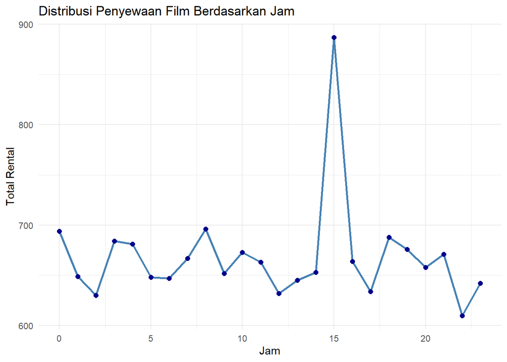

```r
hourly <- df %>%
  group_by(rental_hour) %>%
  summarise(total = n(), .groups = 'drop')

ggplot(hourly, aes(x = rental_hour, y = total)) +
  geom_line(color = "steelblue", size = 1) +
  geom_point(color = "darkblue", size = 2) +
  labs(title = "Distribusi Penyewaan Film Berdasarkan Jam", x = "Jam", y = "Total Rental") +
  theme_minimal()
```

Berdasarkan grafik tren harian, aktivitas penyewaan film menunjukkan pola yang fluktuatif dengan jumlah transaksi yang relatif stabil pada kisaran 600–700 rental di hampir seluruh jam pengamatan. Namun, terdapat lonjakan yang sangat signifikan pada pukul 15:00 dengan total rental mendekati 900 transaksi. Kondisi ini mengindikasikan adanya *peak business hour* pada sore hari, yaitu ketika aktivitas penyewaan mencapai titik tertinggi dibandingkan jam lainnya. Secara umum, meskipun pola rental cenderung stabil, terdapat waktu tertentu yang menunjukkan peningkatan permintaan secara drastis.

Untuk menghitung volume aktivitas penyewaan film secara temporal pada setiap titik waktu $t$ (baik skala jam maupun hari) dari total data populasi sebesar $n$, digunakan fungsi indikator matematika sebagai berikut:

$$f(t) = \sum_{i=1}^{n} I(rental\_hour_i = t)$$

## 7.2 Peak Rental Day

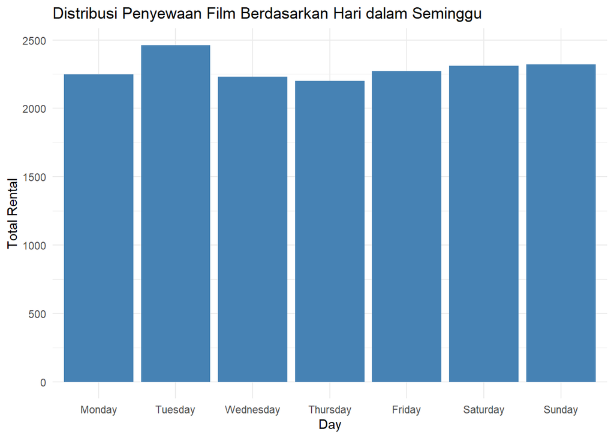

```r
daily <- df %>%
  group_by(rental_day) %>%
  summarise(total = n(), .groups = 'drop')


hari_urut <- c("Monday", "Tuesday", "Wednesday", "Thursday", "Friday", "Saturday", "Sunday")
daily$rental_day <- factor(daily$rental_day, levels = hari_urut)

ggplot(daily, aes(x = rental_day, y = total)) +
  geom_col(fill = "steelblue") +
  labs(title = "Distribusi Penyewaan Film Berdasarkan Hari dalam Seminggu", x = "Day", y = "Total Rental") +
  theme_minimal()
```

Berdasarkan grafik *Peak Rental Day*, distribusi volume penyewaan film mingguan cenderung stabil dan merata pada rentang 2.200 hingga 2.300 transaksi. Meskipun demikian, terdapat lonjakan aktivitas yang signifikan pada hari Selasa (Tuesday) sebagai waktu puncak operasional (Peak Day) dengan total transaksi mencapai hampir 2.500 rental. Hal ini menunjukkan bahwa hari Selasa merupakan *peak day* atau hari dengan volume penyewaan tertinggi dalam periode pengamatan.

Untuk menghitung volume aktivitas penyewaan film secara temporal pada setiap kategori hari $d$ dari total data populasi sebesar $n$, digunakan fungsi indikator matematika sebagai berikut:

$$g(d) = \sum_{i=1}^{n} I(rental\_day_i = d)$$

## 7.3 Weekday vs Weekend

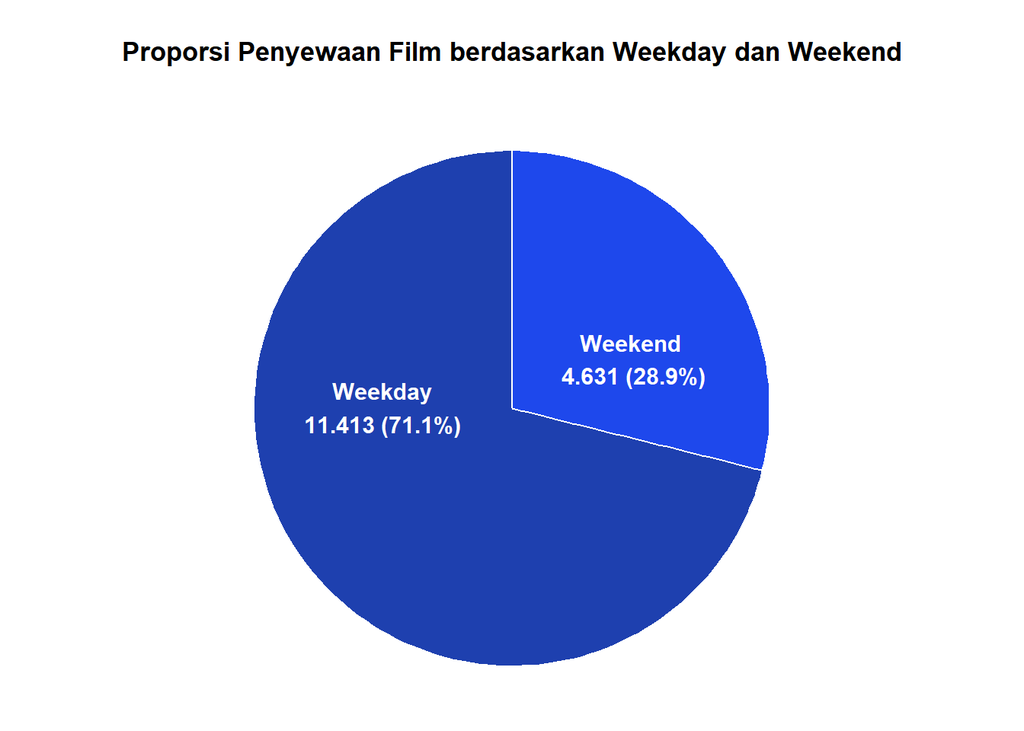

```r
df_pie <- df %>%
  count(day_type) %>%
  mutate(
    persen = n / sum(n),

    label_teks = paste0(day_type, "\n", format(n, big.mark = "."), " (", scales::percent(persen, accuracy = 0.1), ")")
  )


ggplot(df_pie, aes(x = "", y = n, fill = day_type)) +
  geom_col(color = "white", size = 1.5, show.legend = FALSE) +
  coord_polar("y", start = 0) +
  geom_text(aes(label = label_teks),
            position = position_stack(vjust = 0.65),
            color = "white",
            size = 4,
            fontface = "bold") +
  labs(title = "Proporsi Penyewaan Film berdasarkan Weekday dan Weekend",
       x = NULL, y = NULL) +
  scale_fill_manual(values = c("Weekday" = "#1e40af", "Weekend" = "#1e48ec")) +
  theme_void() +
  theme( plot.title = element_text(
      hjust = 0.5,
      face = "bold",
      size = 13,
      margin = margin(t = 20, b = 10)
  ))
```

Berdasarkan grafik *Weekday* vs *Weekend* Rental, volume akumulasi transaksi terbesar berada pada kategori *Weekday* dengan total 11.413 rental, sementara *Weekend* mencatat 4.631 rental. Namun, secara statistika, perbedaan mencolok ini disebabkan oleh ketidakseimbangan jumlah hari pembanding (5 hari kerja banding 2 hari akhir pekan). Jika dihitung berdasarkan rata-rata harian, kedua kategori menghasilkan produktivitas yang setara yaitu sekitar 2.300 transaksi per hari, mengindikasikan pola kedatangan pelanggan yang cenderung konsisten sepanjang minggu.

Untuk mengukur tingkat produktivitas aktivitas penyewaan film secara adil tanpa adanya bias akibat perbedaan jumlah hari antara kategori *weekday* (5 hari) dan *weekend* (2 hari), dilakukan perhitungan nilai rata-rata transaksi harian ($\bar{x}_{\text{day}}$) melalui formula berikut:

$$\bar{x}_{\text{day}} = \frac{\sum_{i=1}^{N_{\text{category}}}
x_i}{N_{\text{category}}}$$

Dimana $\bar{x}_{\text{day}}$ melambangkan nilai rata-rata transaksi harian untuk kategori tipe hari tertentu, $x_i$ menyatakan jumlah akumulasi transaksi pada hari ke-$i$ di dalam kategori tersebut, dan $N_{\text{category}}$ merupakan konstanta jumlah hari pembanding (bernilai 5 untuk *Weekday* dan 2 untuk *Weekend*).

## 7.4 Heat Map

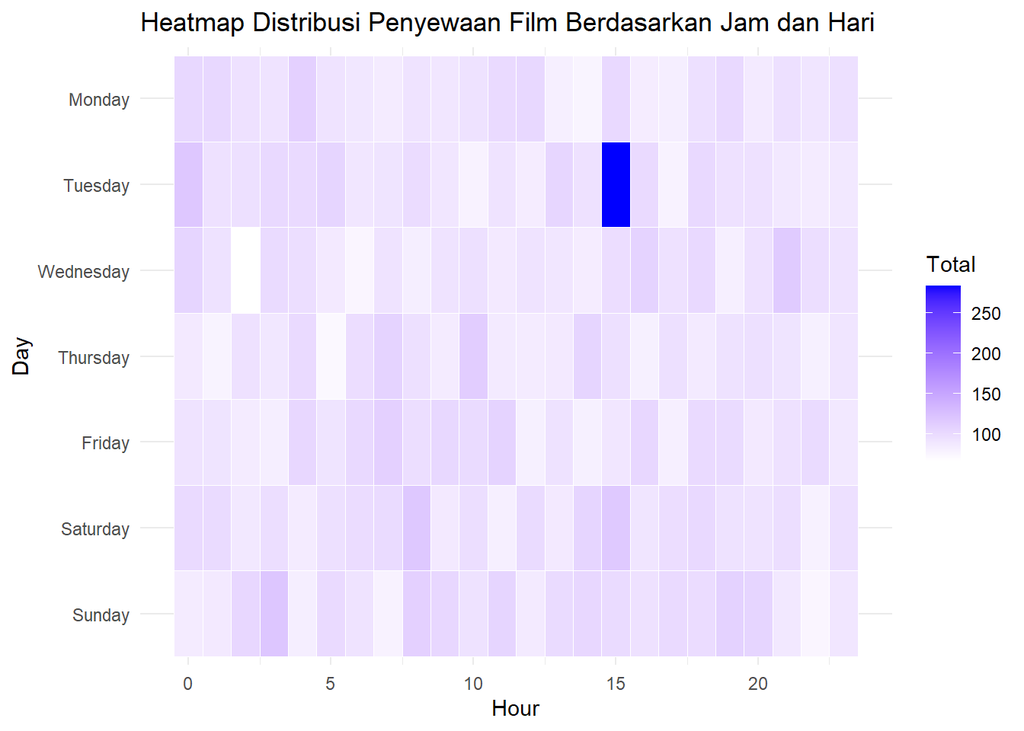

```r
heatmap_data <- df %>%
  group_by(rental_day, rental_hour) %>%
  summarise(total = n(), .groups = 'drop')

# Mengatur urutan hari pada heatmap
heatmap_data$rental_day <- factor(heatmap_data$rental_day, levels = rev(hari_urut))

ggplot(heatmap_data, aes(x = rental_hour, y = rental_day, fill = total)) +
  geom_tile(color = "white") +
  scale_fill_gradient(low = "white", high = "blue") +
  labs(title = "Heatmap Distribusi Penyewaan Film Berdasarkan Jam dan Hari", x = "Hour", y = "Day", fill = "Total") +
  theme_minimal()
```

Berdasarkan visualisasi heat map, terlihat bahwa lonjakan utama berasal dari akumulasi transaksi pada hari Selasa (*Tuesday*) pukul 15.00. Dengan demikian, Selasa (*Tuesday*) pukul 15.00 dapat diidentifikasi sebagai *Peak Business Hour*, yaitu titik waktu operasional dengan volume penyewaan paling tinggi dalam keseluruhan periode pengamatan.

Untuk mengidentifikasi waktu puncak operasional (*Peak Business Hour*) secara akurat dan objektif, ditentukan titik waktu optimal ($t^{*}$) yang menghasilkan frekuensi penyewaan tertinggi menggunakan fungsi optimasi Arguments of the Maximum berikut:

$$t^* = \arg\max_{t} f(t)$$

# 8 Insight Akhir

Hasil analisis menunjukkan adanya konsentrasi distribusi transaksi yang tidak merata secara temporal. Puncak aktivitas (*Peak hour*) terjadi pada sore hari, sedangkan puncak mingguan (*Peak day*) berada pada hari **Selasa**, yang secara empiris memiliki frekuensi transaksi tertinggi dibandingkan hari lainnya.

## 8.1 Interpretasi Akhir dan Evaluasi Kritis

Hasil analisis deskriptif menunjukkan adanya konsentrasi distribusi transaksi yang tidak merata secara temporal. Puncak aktivitas harian (*peak hour*) secara konsisten terjadi pada sore hari (pukul 15:00), sedangkan puncak mingguan (*peak day*) berada pada hari **Selasa**, yang secara empiris memiliki frekuensi transaksi tertinggi dibandingkan hari lainnya dalam seminggu.

# 9 Rekomendasi

## 9.1 Rekomendasi Strategi Bisnis

Berdasarkan hasil analisis perusahaan dapat menerapkan strategi operasional berbasis kapasitas untuk mengoptimalkan efisiensi biaya dan distribusi transaksi penyewaan film pada database Sakila: